# PA 6.2

Author

Alexandra Grover

Published

October 30,2024

# Palmer Penguins Modeling

Import the Palmer Penguins dataset and print out the first few rows.

Suppose we want to predict `bill_depth_mm` using the other variables in the dataset.

Which variables would we need to **dummify**?

```python
import pandas as pd
from sklearn.pipeline import Pipeline
from sklearn.linear_model import LinearRegression
from sklearn.metrics import r2_score
from sklearn.preprocessing import OneHotEncoder
#OneHotEncoder in the sklearn library
```

```python
from palmerpenguins import load_penguins
import pandas as pd
```

```python
penguins = load_penguins()
penguins=penguins.dropna()
penguins.head()
```

|  | species | island | bill_length_mm | bill_depth_mm | flipper_length_mm | body_mass_g | sex | year |
| --- | --- | --- | --- | --- | --- | --- | --- | --- |
| 0 | Adelie | Torgersen | 39.1 | 18.7 | 181.0 | 3750.0 | male | 2007 |
| 1 | Adelie | Torgersen | 39.5 | 17.4 | 186.0 | 3800.0 | female | 2007 |
| 2 | Adelie | Torgersen | 40.3 | 18.0 | 195.0 | 3250.0 | female | 2007 |
| 4 | Adelie | Torgersen | 36.7 | 19.3 | 193.0 | 3450.0 | female | 2007 |
| 5 | Adelie | Torgersen | 39.3 | 20.6 | 190.0 | 3650.0 | male | 2007 |

When you don’t specifiy the variable, it turns all categorical variables to dummy. This can be dangerous of you do not have variables set correctly. FOr example names.

```python
#Using pd.get_dummies

pd.get_dummies(penguins[["species"]]).head()
```

|  | species_Adelie | species_Chinstrap | species_Gentoo |
| --- | --- | --- | --- |
| 0 | True | False | False |
| 1 | True | False | False |
| 2 | True | False | False |
| 4 | True | False | False |
| 5 | True | False | False |

```python
enc = OneHotEncoder()
enc.fit(penguins[["species"]])
enc.transform(penguins[["species"]]).toarray()
```

[output not shown]

[output cut: 278 more lines]

[output not shown]

```python
from sklearn.preprocessing import StandardScaler

scaler= StandardScaler()
scaler.fit_transform(penguins[["bill_length_mm"]])
```

[output not shown]

[output cut: 278 more lines]

[output not shown]

Let’s use `bill_length_mm` to predict `bill_depth_mm`. Prepare your data and fit the following models on the entire dataset:

- Simple linear regression (e.g. straight-line) model
- Quadratic (degree 2 polynomial) model
- Cubic (degree 3 polynomial) model
- Degree 10 polynomial model

Make predictions for each model and plot your fitted models on the scatterplot.

```python
#X["x_sq"] = X["x"]**2
#X["X_cube"] = X["x"]**3
```

```python
#penguins['bill_depth_mm']=penguins['bill_depth_mm'].dropna()
#penguins['bill_length_mm']=penguins['bill_length_mm'].dropna()
```

```python
pd.get_dummies(penguins[["species"]]).head()
```

|  | species_Adelie | species_Chinstrap | species_Gentoo |
| --- | --- | --- | --- |
| 0 | True | False | False |
| 1 | True | False | False |
| 2 | True | False | False |
| 4 | True | False | False |
| 5 | True | False | False |

```python
from sklearn.neighbors import KNeighborsRegressor
from sklearn.tree import DecisionTreeRegressor
from sklearn.linear_model import LinearRegression

lr = LinearRegression()
```

```python
# Let's use bill_length_mm to predict bill_depth_mm. Prepare your data and fit the following models on the entire dataset:
#Simple linear regression (e.g. straight-line) model

X= penguins[["bill_length_mm"]]
Y= penguins["bill_depth_mm"]

#create training
from sklearn.model_selection import train_test_split
X_train, X_test, y_train, y_test = train_test_split(X, Y, test_size=0.25)

#fit the data on training set
lr_fit = lr.fit(X_train, y_train)


#This finds slope
lr_fit.coef_
```

```
array([-0.0962489])
```

```python
#use the fitted model to predict
ytrain_preds= lr_fit.predict(X_train)
ytest_preds = lr_fit.predict(X_test)
ytest_preds
ytrain_preds
```

[output not shown]

```python
#Find MSE
from sklearn.metrics import mean_squared_error

#linear reg
MSE_lr= mean_squared_error(y_test, ytest_preds)
print(MSE_lr)
```

```
3.6845043346324373
```

```python
r2_test= r2_score(y_test, ytest_preds)
r2_train= r2_score(y_train, ytrain_preds)
print(r2_test)
print(r2_train)
```

```
-0.005387097547832509
0.06828344508132567
```

```python
from plotnine import *
```

```python
pred = lr_fit.predict(X)
```

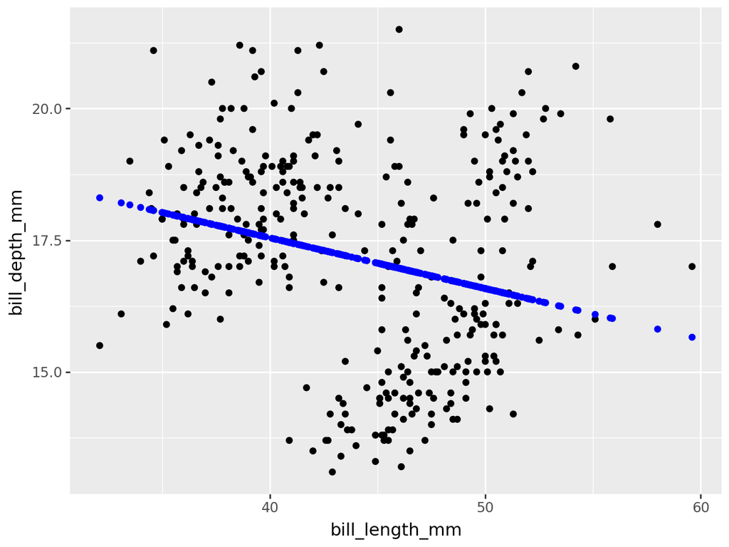

```python
 (ggplot(penguins, aes(x="bill_length_mm", y="bill_depth_mm"))
+ geom_point()
+geom_point(aes(y=pred), color="blue")
)
```

```python
final_model = lr.fit(X, Y)
#slope
final_model.coef_
```

```
array([-0.08232675])
```

```python
penguins['length2'] = penguins['bill_length_mm']**2
penguins['length3'] = penguins['bill_length_mm']**3
penguins['length4'] = penguins['bill_length_mm']**4
penguins['length5'] = penguins['bill_length_mm']**5
penguins['length6'] = penguins['bill_length_mm']**6
penguins['length7'] = penguins['bill_length_mm']**7
penguins['length8'] = penguins['bill_length_mm']**8
penguins['length9'] = penguins['bill_length_mm']**9
penguins['length10'] = penguins['bill_length_mm']**10
```

```python
#model 2

X2= penguins[["bill_length_mm", "length2"]]
Y2= penguins["bill_depth_mm"]
lr = LinearRegression()
#create training
from sklearn.model_selection import train_test_split
X2_train, X2_test, y2_train, y2_test = train_test_split(X2, Y2, test_size=0.25)

#fit the data on training set
lr_fit2 = lr.fit(X2_train, y2_train)


Xtrain_preds2 = lr_fit2.predict(X2_train)
Xtest_preds2 = lr_fit2.predict(X2_test)


#cube MSE 2
MSE_lr2= mean_squared_error(y2_test, Xtest_preds2)
print(MSE_lr2)
#rsquared model 2
r2_test2= r2_score(y2_test, Xtest_preds2)
r2_train2= r2_score(y2_train, Xtrain_preds2)
print(r2_test2)
print(r2_train2)
```

```
3.2337979154180365
0.11989309234041345
0.10275736257361334
```

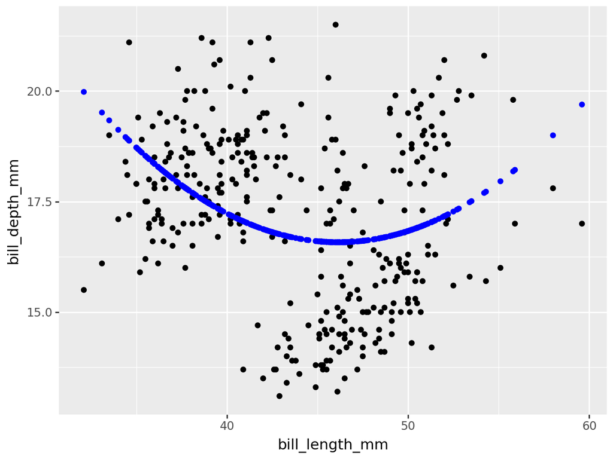

```python
pred2 = lr_fit2.predict(X2)
(ggplot(penguins, aes(x="bill_length_mm", y="bill_depth_mm"))
+ geom_point()
+geom_point(aes(y=pred2), color="blue")
)
```

```python
X3= penguins[["bill_length_mm", "length2","length3"]]
Y3= penguins["bill_depth_mm"]
lr = LinearRegression()
```

```python
#cubing: model 3


#create training
from sklearn.model_selection import train_test_split
X3_train, X3_test, y3_train, y3_test = train_test_split(X3, Y3, test_size=0.25)

#fit the data on training set
lr_fit3= lr.fit(X3_train, y3_train)

Xtrain_preds3 = lr_fit3.predict(X3_train)
Xtest_preds3 = lr_fit3.predict(X3_test)
```

```python
#MSE model 3
MSE_lr3= mean_squared_error(y3_test, Xtest_preds3)
print(MSE_lr3)
```

```
3.1024807538865997
```

```python
#rsquared model 3
r2_test3= r2_score(y3_test, Xtest_preds3)
r2_train3= r2_score(y3_train, Xtrain_preds3)
print(r2_test3)
print(r2_train3)
```

```
0.10998168015014287
0.13610734637754385
```

```python
final_model = lr.fit(X3, Y3)
final_model.coef_
```

```
array([ 6.77963360e+00, -1.68915134e-01,  1.36264370e-03])
```

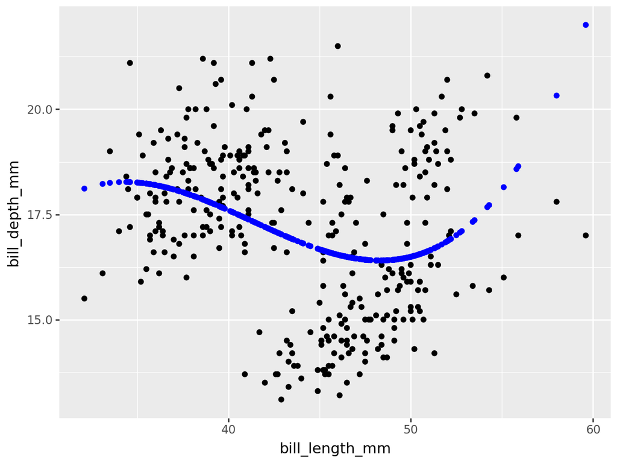

```python
pred3 = lr_fit3.predict(X3)
(ggplot(penguins, aes(x="bill_length_mm", y="bill_depth_mm"))
+ geom_point()
+geom_point(aes(y=pred3), color="blue")
)
```

- Are any of the models above underfitting the data? If so, which ones and how can you tell?
- Are any of thhe models above overfitting the data? If so, which ones and how can you tell?
- Which of the above models do you think fits the data best and why?

```python
X10= penguins[["bill_length_mm", "length2", "length3", "length4", "length5", "length6", "length7", "length8", "length9", "length10"]]
Y10= penguins["bill_depth_mm"]
lr = LinearRegression()
```

```python
#cubing: model 10


#create training
from sklearn.model_selection import train_test_split
X10_train, X10_test, y10_train, y10_test = train_test_split(X10, Y10, test_size=0.25)

#fit the data on training set
lr_fit10= lr.fit(X10_train, y10_train)

Xtrain_preds10 = lr_fit10.predict(X10_train)
Xtest_preds10 = lr_fit10.predict(X10_test)
```

```python
#MSE model 10
MSE_lr10= mean_squared_error(y10_test, Xtest_preds10)
print(MSE_lr10)
```

```
4.586268334566067
```

```python
#rsquared model 10
r2_test10= r2_score(y10_test, Xtest_preds10)
r2_train10= r2_score(y10_train, Xtrain_preds10)
print(r2_test10)
print(r2_train10)
```

```
-0.1422851332765558
0.2962206313484187
```

```python
final_model = lr.fit(X10, Y10)
final_model.coef_
```

```
array([-1.12014562e-09, -3.66777769e-08, -1.10276038e-06, -1.87892804e-05,
       -1.75581476e-04,  1.68768691e-05, -6.56036467e-07,  1.28398393e-08,
       -1.26066731e-10,  4.95524578e-13])
```

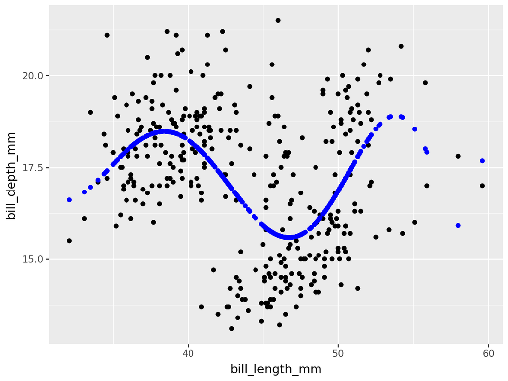

```python
pred10 = lr_fit10.predict(X10)
(ggplot(penguins, aes(x="bill_length_mm", y="bill_depth_mm"))
+ geom_point()
+geom_point(aes(y=pred10), color="blue")
)
```